# IE582 Homework 2

```r
skim(glioma_data)
```

Data summary

| Name | glioma_data |
| --- | --- |
| Number of rows | 839 |
| Number of columns | 24 |
| _______________________ |  |
| Column type frequency: |  |
| character | 2 |
| numeric | 22 |
| ________________________ |  |
| Group variables | None |

**Variable type: character**

| skim_variable | n_missing | complete_rate | min | max | empty | n_unique | whitespace |
| --- | --- | --- | --- | --- | --- | --- | --- |
| Grade | 0 | 1 | 3 | 3 | 0 | 2 | 0 |
| IDH1 | 0 | 1 | 7 | 11 | 0 | 2 | 0 |

**Variable type: numeric**

| skim_variable | n_missing | complete_rate | mean | sd | p0 | p25 | p50 | p75 | p100 | hist |
| --- | --- | --- | --- | --- | --- | --- | --- | --- | --- | --- |
| Gender | 0 | 1 | 0.42 | 0.49 | 0.00 | 0.00 | 0.00 | 1.0 | 1.00 | ▇▁▁▁▆ |
| Age_at_diagnosis | 0 | 1 | 50.94 | 15.70 | 14.42 | 38.06 | 51.55 | 62.8 | 89.29 | ▂▇▇▇▂ |
| Race | 0 | 1 | 0.11 | 0.37 | 0.00 | 0.00 | 0.00 | 0.0 | 3.00 | ▇▁▁▁▁ |
| TP53 | 0 | 1 | 0.41 | 0.49 | 0.00 | 0.00 | 0.00 | 1.0 | 1.00 | ▇▁▁▁▆ |
| ATRX | 0 | 1 | 0.26 | 0.44 | 0.00 | 0.00 | 0.00 | 1.0 | 1.00 | ▇▁▁▁▃ |
| PTEN | 0 | 1 | 0.17 | 0.37 | 0.00 | 0.00 | 0.00 | 0.0 | 1.00 | ▇▁▁▁▂ |
| EGFR | 0 | 1 | 0.13 | 0.34 | 0.00 | 0.00 | 0.00 | 0.0 | 1.00 | ▇▁▁▁▁ |
| CIC | 0 | 1 | 0.13 | 0.34 | 0.00 | 0.00 | 0.00 | 0.0 | 1.00 | ▇▁▁▁▁ |
| MUC16 | 0 | 1 | 0.12 | 0.32 | 0.00 | 0.00 | 0.00 | 0.0 | 1.00 | ▇▁▁▁▁ |
| PIK3CA | 0 | 1 | 0.09 | 0.28 | 0.00 | 0.00 | 0.00 | 0.0 | 1.00 | ▇▁▁▁▁ |
| NF1 | 0 | 1 | 0.08 | 0.27 | 0.00 | 0.00 | 0.00 | 0.0 | 1.00 | ▇▁▁▁▁ |
| PIK3R1 | 0 | 1 | 0.06 | 0.25 | 0.00 | 0.00 | 0.00 | 0.0 | 1.00 | ▇▁▁▁▁ |
| FUBP1 | 0 | 1 | 0.05 | 0.23 | 0.00 | 0.00 | 0.00 | 0.0 | 1.00 | ▇▁▁▁▁ |
| RB1 | 0 | 1 | 0.05 | 0.21 | 0.00 | 0.00 | 0.00 | 0.0 | 1.00 | ▇▁▁▁▁ |
| NOTCH1 | 0 | 1 | 0.05 | 0.21 | 0.00 | 0.00 | 0.00 | 0.0 | 1.00 | ▇▁▁▁▁ |
| BCOR | 0 | 1 | 0.03 | 0.18 | 0.00 | 0.00 | 0.00 | 0.0 | 1.00 | ▇▁▁▁▁ |
| CSMD3 | 0 | 1 | 0.03 | 0.18 | 0.00 | 0.00 | 0.00 | 0.0 | 1.00 | ▇▁▁▁▁ |
| SMARCA4 | 0 | 1 | 0.03 | 0.18 | 0.00 | 0.00 | 0.00 | 0.0 | 1.00 | ▇▁▁▁▁ |
| GRIN2A | 0 | 1 | 0.03 | 0.18 | 0.00 | 0.00 | 0.00 | 0.0 | 1.00 | ▇▁▁▁▁ |
| IDH2 | 0 | 1 | 0.03 | 0.16 | 0.00 | 0.00 | 0.00 | 0.0 | 1.00 | ▇▁▁▁▁ |
| FAT4 | 0 | 1 | 0.03 | 0.16 | 0.00 | 0.00 | 0.00 | 0.0 | 1.00 | ▇▁▁▁▁ |
| PDGFRA | 0 | 1 | 0.03 | 0.16 | 0.00 | 0.00 | 0.00 | 0.0 | 1.00 | ▇▁▁▁▁ |

Can be seen in the data, there is no missing values, which is a good sign for us. First, we need to factorize the target value `Grade`. Then, we also need to execute the encoding operation for the feature `IDH1`. We are going to use one-hot-encoding operation to split “MUTATED” and “NOT MUTATED” to the numeric values.

```r
glioma_data$Grade <- as.factor(glioma_data$Grade)

# One hot encoding
glioma_data <- glioma_data %>%
  mutate(IDH1 = as.factor(IDH1)) %>%
  bind_cols(model.matrix(~ IDH1 - 1, data = .)) %>%
  select(-IDH1)  # Drop the original 'IDH1' column
```

We are ready to move on. Let’s make some visualizations to understand data more. It can be seen that There is an imbalance in the class (target) variable between `GBM` and `LGG`. Looks like there is balance between multiclass targets.

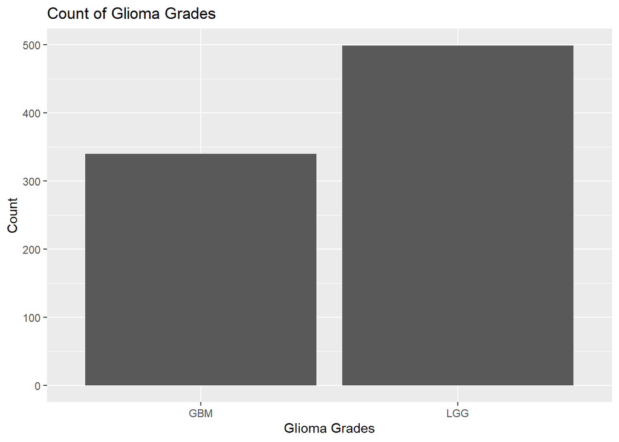

```r
ggplot(glioma_data, aes(x = Grade )) +
  geom_bar(stat = "count") +
  labs(title = "Count of Glioma Grades", x = "Glioma Grades", y = "Count")
```

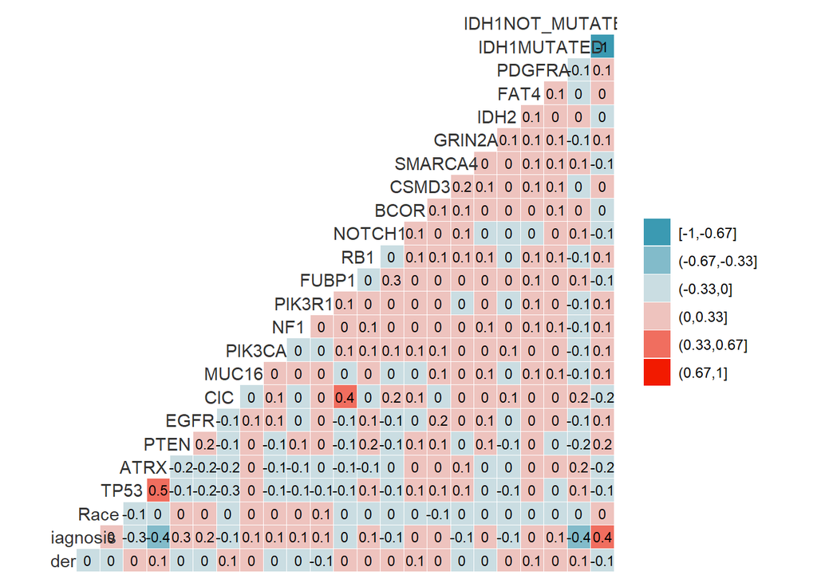

```r
ggcorr(glioma_data,
       method = c("pairwise"),
       nbreaks = 6,
       hjust = 0.8,
       label = TRUE,
       label_size = 3,
       color = "grey20")
```

### Part 4.2 : Train & Test Split for Modeling (Scaled Split)

In order to train the model and then the test its performance, we need to split the data as training and test datasets. Before hand, we also need to scale the features (except the target feature) while using the K-Nearest-Neighbor algorithm since it is highly affected from feature’s scale.

In order not to mutate the main dataset, we’ll copy it and then make the scale and split operation.

```r
scaled_glioma_data <- glioma_data
scaled_glioma_data[,-1] <- scale(scaled_glioma_data[,-1])

validationIndex <- createDataPartition(scaled_glioma_data$Grade, p=0.70, list=FALSE)

knn_train <- scaled_glioma_data[validationIndex,] # 70% of data to training
knn_test <- scaled_glioma_data[-validationIndex,]


cat("Dimension of the main dataset:",dim(scaled_glioma_data))
```

```
## Dimension of the main dataset: 839 25
```

```r
cat("Dimension of the train dataset:",dim(knn_train))
```

```
## Dimension of the train dataset: 588 25
```

```r
cat("Dimension of the test dataset:",dim(knn_test))
```

```
## Dimension of the test dataset: 251 25
```

Dataset is scaled, has no missing and duplicated values. It is ready to be used in algorithms.

### Part 4.3 : kNN Algorithm (k-Nearest Neighbor)

Let’s start with the kNN algorithm. The algorithm is based on the idea that similar data points tend to be close to each other in the feature space. In other words, the class or value of an unknown data point can be predicted by examining its k-nearest neighbors.

There are two parameters to consider: the distance measure and the number of neighbors. We are mainly interested in two distance measures in this assignment: Euclidean and Manhattan Distance.

Let’s do the Cross Validation to find the optimal k (# of nearest neighbor):

```r
# 10-fold Cross Validation
trainControl <- trainControl(method="repeatedcv", number=10, repeats=5)
metric <- "Accuracy"
set.seed(8)

# kNN Part
fit.knn <- train(Grade~., data=knn_train, method="knn",
                 metric=metric ,trControl=trainControl)
knn.optimal.k <- fit.knn$bestTune # keep this Initial k for testing with knn() function in next section

print(fit.knn)
```

```
## k-Nearest Neighbors
##
## 588 samples
##  24 predictor
##   2 classes: 'GBM', 'LGG'
##
## No pre-processing
## Resampling: Cross-Validated (10 fold, repeated 5 times)
## Summary of sample sizes: 529, 529, 530, 529, 530, 529, ...
## Resampling results across tuning parameters:
##
##   k  Accuracy   Kappa
##   5  0.8713676  0.7351490
##   7  0.8696493  0.7320719
##   9  0.8709994  0.7345634
##
## Accuracy was used to select the optimal model using the largest value.
## The final value used for the model was k = 5.
```

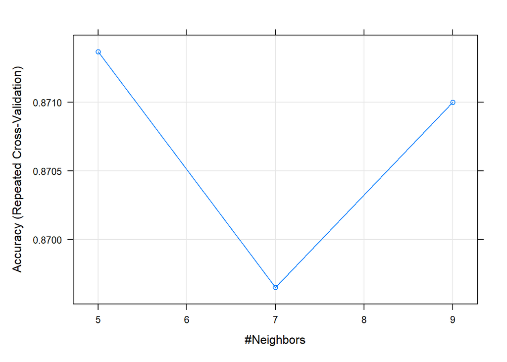

```r
plot(fit.knn)
```

Accuracy was used to select the optimal model using the largest value. After the report of the CV and the plot shows that the final value used for the model was k = 5 and it is the optimum k value for the model.

Confusion matrix for k = 5 is as follows:

```r
prediction <- predict(fit.knn, newdata = knn_test)
cm_knn <- confusionMatrix(prediction, knn_test$Grade)
print(cm_knn)
```

```
## Confusion Matrix and Statistics
##
##           Reference
## Prediction GBM LGG
##        GBM  91  13
##        LGG  11 136
##
##                Accuracy : 0.9044
##                  95% CI : (0.8611, 0.9378)
##     No Information Rate : 0.5936
##     P-Value [Acc > NIR] : <2e-16
##
##                   Kappa : 0.8024
##
##  Mcnemar's Test P-Value : 0.8383
##
##             Sensitivity : 0.8922
##             Specificity : 0.9128
##          Pos Pred Value : 0.8750
##          Neg Pred Value : 0.9252
##              Prevalence : 0.4064
##          Detection Rate : 0.3625
##    Detection Prevalence : 0.4143
##       Balanced Accuracy : 0.9025
##
##        'Positive' Class : GBM
##
```

Let’s do the analysis for different types of k such as the floor of square root of the dataset size (row)

```r
initial_k <- sqrt(NROW(scaled_glioma_data))
initial_k
```

```
## [1] 28.9655
```

```r
knn.floor <- knn(train=knn_train[,-1], test=knn_test[,-1],
                 cl=knn_train$Grade, k=floor(initial_k))

# use confusion matrix to calculate accuracy
cm.floor <- confusionMatrix(knn_test$Grade,knn.floor)
cm.floor
```

```
## Confusion Matrix and Statistics
##
##           Reference
## Prediction GBM LGG
##        GBM  92  10
##        LGG  13 136
##
##                Accuracy : 0.9084
##                  95% CI : (0.8657, 0.941)
##     No Information Rate : 0.5817
##     P-Value [Acc > NIR] : <2e-16
##
##                   Kappa : 0.811
##
##  Mcnemar's Test P-Value : 0.6767
##
##             Sensitivity : 0.8762
##             Specificity : 0.9315
##          Pos Pred Value : 0.9020
##          Neg Pred Value : 0.9128
##              Prevalence : 0.4183
##          Detection Rate : 0.3665
##    Detection Prevalence : 0.4064
##       Balanced Accuracy : 0.9038
##
##        'Positive' Class : GBM
##
```

Finally, lets also look at the model with Manhattan distance using `kknn` library.

```r
knn.manhattan <- train.kknn(Grade ~ ., data = knn_train, ks = 5, scale = TRUE, distance = 1)
predictions.manhattan <- predict(knn.manhattan, newdata = knn_test)

cm.manhattan <- table(predictions.manhattan, knn_test$Grade)
print(cm.manhattan)
```

```
##
## predictions.manhattan GBM LGG
##                   GBM  90  17
##                   LGG  12 132
```

```r
accuracy.manhattan <- sum(diag(cm.manhattan)) / sum(cm.manhattan)
print(paste("Accuracy for kNN with Manhattan Distance:", round(accuracy.manhattan,5)))
```

```
## [1] "Accuracy for kNN with Manhattan Distance: 0.88446"
```

### Part 4.4 : Decision Tree Algorithm

Let’s move with the second one which is the Decision Tree (DT) algorithm.

First, arranging the dataset in order not to mutate original one, we copy from it.

```r
# Copying the main dataset
glioma_data_dt <- data.table(glioma_data)

head(glioma_data_dt)
```

```
##    Grade Gender Age_at_diagnosis Race TP53 ATRX PTEN EGFR CIC MUC16 PIK3CA NF1
## 1:   LGG      0            51.30    0    0    0    0    0   0     0      1   0
## 2:   LGG      0            38.72    0    0    0    0    0   1     0      0   0
## 3:   LGG      0            35.17    0    1    1    0    0   0     0      0   0
## 4:   LGG      1            32.78    0    1    1    0    0   0     1      0   0
## 5:   LGG      0            31.51    0    1    1    0    0   0     0      0   0
## 6:   LGG      1            33.21    0    0    1    0    0   0     0      0   0
##    PIK3R1 FUBP1 RB1 NOTCH1 BCOR CSMD3 SMARCA4 GRIN2A IDH2 FAT4 PDGFRA
## 1:      0     1   0      0    0     0       0      0    0    0      0
## 2:      0     0   0      0    0     0       0      0    0    0      0
## 3:      0     0   0      0    0     0       0      0    0    0      0
## 4:      1     0   0      0    0     0       0      0    0    1      0
## 5:      0     0   0      0    0     0       0      0    0    0      0
## 6:      0     0   0      0    0     0       0      0    0    0      0
##    IDH1MUTATED IDH1NOT_MUTATED
## 1:           1               0
## 2:           1               0
## 3:           1               0
## 4:           1               0
## 5:           1               0
## 6:           1               0
```

```r
dim(glioma_data_dt)
```

```
## [1] 839  25
```

```r
# Remove rows with any NA values
glioma_data_dt <- na.omit(glioma_data_dt)
validationIndex <- createDataPartition(glioma_data_dt$Grade, p=0.70, list=FALSE)

dt_train <- glioma_data_dt[validationIndex,] # 70% of data to training
dt_test <- glioma_data_dt[-validationIndex,]

cat("Dimension of the main dataset:",dim(glioma_data_dt))
```

```
## Dimension of the main dataset: 839 25
```

```r
cat("Dimension of the train dataset:",dim(dt_train))
```

```
## Dimension of the train dataset: 588 25
```

```r
cat("Dimension of the test dataset:",dim(dt_test))
```

```
## Dimension of the test dataset: 251 25
```

Dataset is ready to be learned and now we are going to implement a manual cross validation to tune the hyperparameters for the decision tree and we are going to look at its Accuracy value in each iteration.

Assuming the tuning hyperparameter will be only the minimal number of observations per tree leaf. Setting complexity parameter to zero and minimum number of observations to split as the twice as the minimal number of observations per tree leaf.

In the end, we are going to store them in df to find the best model.

```r
# Create a data frame to store cross-validation results
cv_results <- data.frame(minbucket = numeric(), accuracy = numeric())

set.seed(10)

# Define a range of minsplit values to try
minbucket_values <- c(1, 5, 10, 15, 20)

# Perform cross-validation for each minbucket value
for (minbucket_val in minbucket_values) {
  # Create a decision tree model with the current minbucket value
  tree_model <- rpart(Grade~.,dt_train,method='class',
                      control=rpart.control(cp=0, minbucket = minbucket_val, minsplit = 2*minbucket_val))

  predictions <- predict(tree_model, newdata = dt_train, type = "class")
  correct_predictions <- sum(predictions == dt_train$Grade)
  # Calculate accuracy
  accuracy <- round(correct_predictions / nrow(dt_train),5)

  # Store the results in the data frame
  cv_results <- rbind(cv_results, data.frame(minbucket = minbucket_val, accuracy = accuracy))
}

# Print the cross-validation results
print(cv_results)
```

```
##   minbucket accuracy
## 1         1  1.00000
## 2         5  0.92517
## 3        10  0.90646
## 4        15  0.88776
## 5        20  0.88776
```

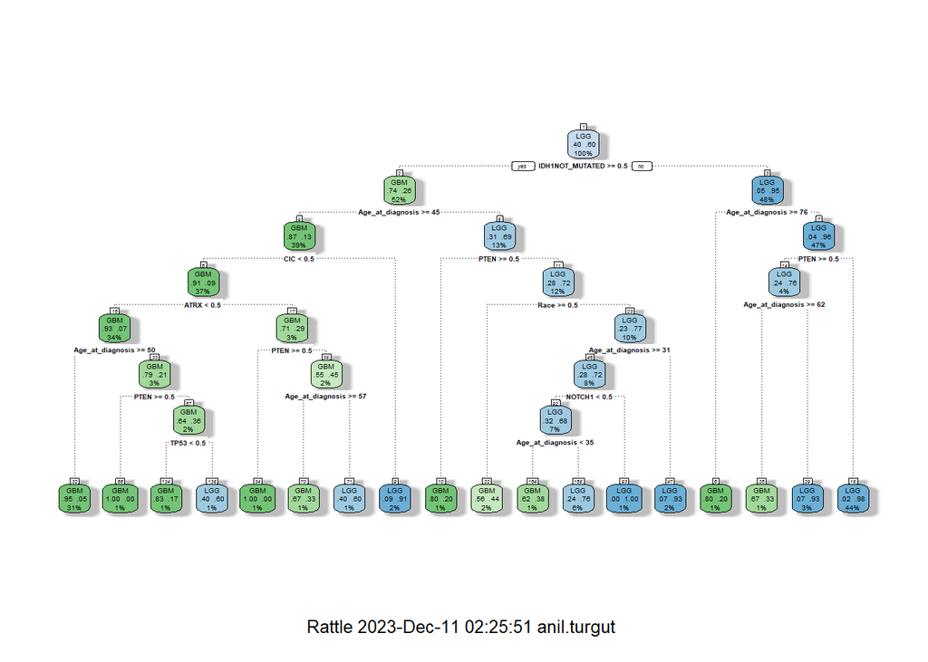

```r
minbucket_val <- 5
best_tree_model <- rpart(Grade~.,dt_train,method='class',
                         control=rpart.control(cp=0, minbucket = minbucket_val, minsplit = 2*minbucket_val))

fancyRpartPlot(best_tree_model)
```

Its confusion matrices with respect to training & test dataset are below. It successfully classifies the target values near 92% with traind and 85% with test dataset.

```r
predictions_model <- predict(best_tree_model, newdata = dt_train, type = "class")
cm_train <- confusionMatrix(predictions_model, dt_train$Grade)
cm_train
```

```
## Confusion Matrix and Statistics
##
##           Reference
## Prediction GBM LGG
##        GBM 218  24
##        LGG  20 326
##
##                Accuracy : 0.9252
##                  95% CI : (0.9008, 0.9451)
##     No Information Rate : 0.5952
##     P-Value [Acc > NIR] : <2e-16
##
##                   Kappa : 0.8451
##
##  Mcnemar's Test P-Value : 0.6511
##
##             Sensitivity : 0.9160
##             Specificity : 0.9314
##          Pos Pred Value : 0.9008
##          Neg Pred Value : 0.9422
##              Prevalence : 0.4048
##          Detection Rate : 0.3707
##    Detection Prevalence : 0.4116
##       Balanced Accuracy : 0.9237
##
##        'Positive' Class : GBM
##
```

```r
predictions_model.test <- predict(best_tree_model, newdata = dt_test, type = "class")
cm_test <- confusionMatrix(predictions_model.test, dt_test$Grade)
cm_test
```

```
## Confusion Matrix and Statistics
##
##           Reference
## Prediction GBM LGG
##        GBM  87  19
##        LGG  15 130
##
##                Accuracy : 0.8645
##                  95% CI : (0.8159, 0.9043)
##     No Information Rate : 0.5936
##     P-Value [Acc > NIR] : <2e-16
##
##                   Kappa : 0.721
##
##  Mcnemar's Test P-Value : 0.6069
##
##             Sensitivity : 0.8529
##             Specificity : 0.8725
##          Pos Pred Value : 0.8208
##          Neg Pred Value : 0.8966
##              Prevalence : 0.4064
##          Detection Rate : 0.3466
##    Detection Prevalence : 0.4223
##       Balanced Accuracy : 0.8627
##
##        'Positive' Class : GBM
##
```

Finally, we can look its ROC curve and AUC score

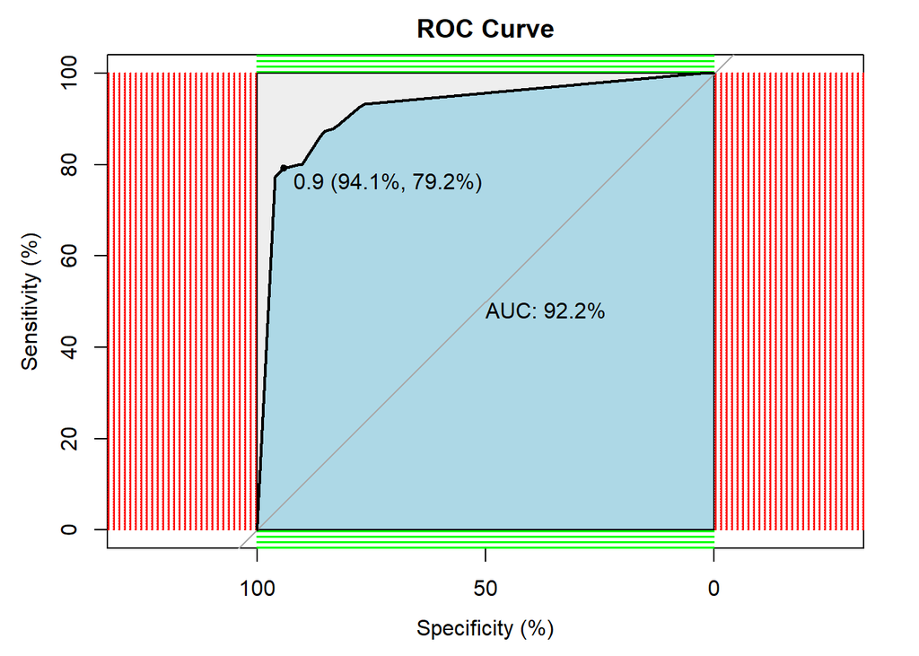

```r
p1 <- predict(best_tree_model, dt_test, type = 'prob')
p1 <- p1[,2]
r <- multiclass.roc(dt_test$Grade, p1, percent = TRUE)
roc <- r[['rocs']]
r1 <- roc[[1]]
plot.roc(r1,
         print.auc=TRUE,
         auc.polygon=TRUE,
         grid=c(0.1, 0.2),
         grid.col=c("green", "red"),
         max.auc.polygon=TRUE,
         auc.polygon.col="lightblue",
         print.thres=TRUE,
         main= 'ROC Curve')
```

### Part 4.5 : Random Forest Algorithm

Let’s move with the third one which is the Random Forest (RF) algorithm.

First, arranging the dataset in order not to mutate original one, we copy from it.

```r
# Copying the main dataset
glioma_data_rf <- data.table(glioma_data)

head(glioma_data_rf)
```

```
##    Grade Gender Age_at_diagnosis Race TP53 ATRX PTEN EGFR CIC MUC16 PIK3CA NF1
## 1:   LGG      0            51.30    0    0    0    0    0   0     0      1   0
## 2:   LGG      0            38.72    0    0    0    0    0   1     0      0   0
## 3:   LGG      0            35.17    0    1    1    0    0   0     0      0   0
## 4:   LGG      1            32.78    0    1    1    0    0   0     1      0   0
## 5:   LGG      0            31.51    0    1    1    0    0   0     0      0   0
## 6:   LGG      1            33.21    0    0    1    0    0   0     0      0   0
##    PIK3R1 FUBP1 RB1 NOTCH1 BCOR CSMD3 SMARCA4 GRIN2A IDH2 FAT4 PDGFRA
## 1:      0     1   0      0    0     0       0      0    0    0      0
## 2:      0     0   0      0    0     0       0      0    0    0      0
## 3:      0     0   0      0    0     0       0      0    0    0      0
## 4:      1     0   0      0    0     0       0      0    0    1      0
## 5:      0     0   0      0    0     0       0      0    0    0      0
## 6:      0     0   0      0    0     0       0      0    0    0      0
##    IDH1MUTATED IDH1NOT_MUTATED
## 1:           1               0
## 2:           1               0
## 3:           1               0
## 4:           1               0
## 5:           1               0
## 6:           1               0
```

```r
dim(glioma_data_rf)
```

```
## [1] 839  25
```

```r
glioma_data_rf <- na.omit(glioma_data_rf)
validationIndex <- createDataPartition(glioma_data_rf$Grade, p=0.70, list=FALSE)

rf_train <- glioma_data_rf[validationIndex,] # 70% of data to training
rf_test <- glioma_data_rf[-validationIndex,]

cat("Dimension of the main dataset:",dim(glioma_data_rf))
```

```
## Dimension of the main dataset: 839 25
```

```r
cat("Dimension of the train dataset:",dim(rf_train))
```

```
## Dimension of the train dataset: 588 25
```

```r
cat("Dimension of the test dataset:",dim(rf_test))
```

```
## Dimension of the test dataset: 251 25
```

Dataset is ready to be learned and now we are going to implement a manual cross validation to tune the hyperparameters for the random forest and we are going to look at its error value in each iteration.

Assuming the tuning hyperparameter will be only the effect of the ratio of the number of features evaluated at each split (mtry) and setting other parameters as J=500 and the minimal number of observations per tree leaf=5.

In the end, we are going to store them in table to find the best model.

```r
set.seed(50)
# CV RF

# Set the number of trees and nodesize
num_trees <- 500
min_obs_per_leaf <- 5

# Create a grid of mtry values to explore
mtry_values <- c(2, 4, 6, 8, 10, 15, 20)  # Add more values as needed

# Create an empty data frame to store results
rf_results <- data.frame(mtry = numeric(0), error_rate = numeric(0))

# Perform grid search
for (m in mtry_values) {
  # Train the Random Forest model
  rf_model <- randomForest(Grade ~ ., data = rf_train,
                           ntree = num_trees, nodesize = min_obs_per_leaf, mtry = m)

  # Make predictions on the training set
  predictions <- predict(rf_model, dt_train)

  # Calculate the error rate (you may want to use a more appropriate metric)
  error_rate <- mean(predictions != rf_train$Grade)

  # Store the results
  rf_results <- rbind(rf_results, data.frame(mtry = m, error_rate = error_rate))
}

# Print the results
print(rf_results)
```

```
##   mtry error_rate
## 1    2 0.07823129
## 2    4 0.06802721
## 3    6 0.06122449
## 4    8 0.05272109
## 5   10 0.05442177
## 6   15 0.04761905
## 7   20 0.04421769
```

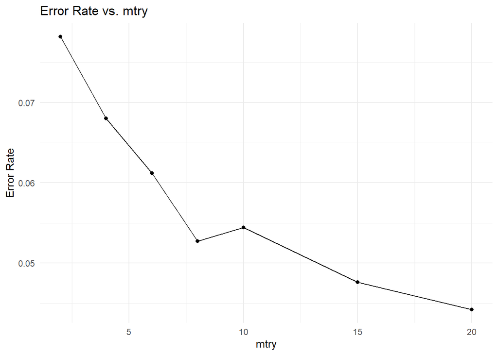

```r
# Create a line plot
ggplot(rf_results, aes(x = mtry, y = error_rate)) +
  geom_line() +
  geom_point() +
  labs(title = "Error Rate vs. mtry",
       x = "mtry",
       y = "Error Rate") +
  theme_minimal()
```

```r
best_rf_model <- randomForest(Grade ~ ., data = rf_train,
                              ntree = num_trees, nodesize = min_obs_per_leaf, mtry = 8)

# Make predictions on the train set
rf_predictions.train <- predict(best_rf_model, newdata = rf_train)

# Create the confusion matrix
rf_confusion_matrix.train <- confusionMatrix(rf_predictions.train, rf_train$Grade)

# Print the confusion matrix
print(rf_confusion_matrix.train)
```

```
## Confusion Matrix and Statistics
##
##           Reference
## Prediction GBM LGG
##        GBM 225  13
##        LGG  13 337
##
##                Accuracy : 0.9558
##                  95% CI : (0.9359, 0.9709)
##     No Information Rate : 0.5952
##     P-Value [Acc > NIR] : <2e-16
##
##                   Kappa : 0.9082
##
##  Mcnemar's Test P-Value : 1
##
##             Sensitivity : 0.9454
##             Specificity : 0.9629
##          Pos Pred Value : 0.9454
##          Neg Pred Value : 0.9629
##              Prevalence : 0.4048
##          Detection Rate : 0.3827
##    Detection Prevalence : 0.4048
##       Balanced Accuracy : 0.9541
##
##        'Positive' Class : GBM
##
```

```r
# Make predictions on the test set
rf_predictions.test <- predict(best_rf_model, newdata = rf_test)

# Create the confusion matrix
rf_confusion_matrix.test <- confusionMatrix(rf_predictions.test, rf_test$Grade)

# Print the confusion matrix
print(rf_confusion_matrix.test)
```

```
## Confusion Matrix and Statistics
##
##           Reference
## Prediction GBM LGG
##        GBM  88  13
##        LGG  14 136
##
##                Accuracy : 0.8924
##                  95% CI : (0.8474, 0.9279)
##     No Information Rate : 0.5936
##     P-Value [Acc > NIR] : <2e-16
##
##                   Kappa : 0.7767
##
##  Mcnemar's Test P-Value : 1
##
##             Sensitivity : 0.8627
##             Specificity : 0.9128
##          Pos Pred Value : 0.8713
##          Neg Pred Value : 0.9067
##              Prevalence : 0.4064
##          Detection Rate : 0.3506
##    Detection Prevalence : 0.4024
##       Balanced Accuracy : 0.8877
##
##        'Positive' Class : GBM
##
```

Its confusion matrices with respect to training & test dataset are above It classifies the target values near 95% wtih the training dataset. Its’ test metrics are also well such as accuracy around 88%.

Finally, let’s look at the variable importance and the partial dependence plots. VarImp plot basically shows which feature has the most contribution to the model while it is improving (making purer). Partial Dependence plot is the plot showing the effect of selected feature to the predictions.

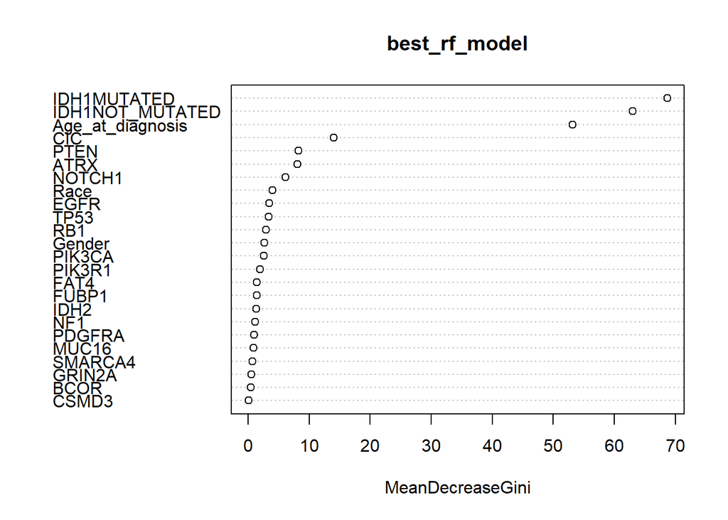

```r
# Plot variable importance
varImpPlot(best_rf_model)
```

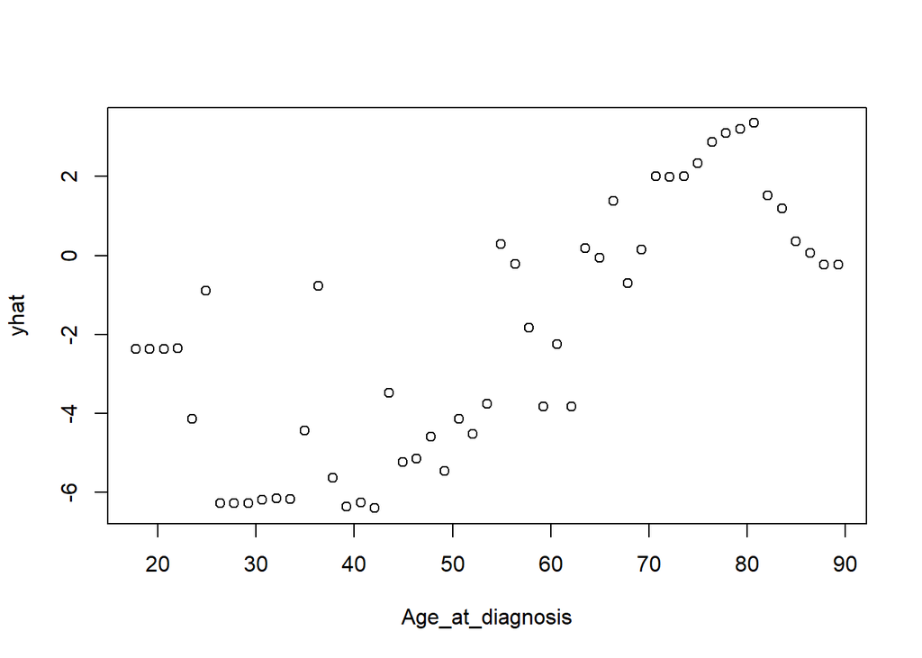

```r
# Create partial dependence plot
partial_plot <- partial(best_rf_model, pred.var = 'Age_at_diagnosis', data = dt_test)

# Plot the partial dependence plot
plot(partial_plot)
```

### Part 4.6 : GBM Algorithm

Let’s move with the third one which is the Gradient Boosting Machine (GBM) algorithm.

First, arranging the dataset in order not to mutate original one, we copy from it.

```r
glioma_data_gbm <- data.table(glioma_data)

head(glioma_data_gbm)
```

```
##    Grade Gender Age_at_diagnosis Race TP53 ATRX PTEN EGFR CIC MUC16 PIK3CA NF1
## 1:   LGG      0            51.30    0    0    0    0    0   0     0      1   0
## 2:   LGG      0            38.72    0    0    0    0    0   1     0      0   0
## 3:   LGG      0            35.17    0    1    1    0    0   0     0      0   0
## 4:   LGG      1            32.78    0    1    1    0    0   0     1      0   0
## 5:   LGG      0            31.51    0    1    1    0    0   0     0      0   0
## 6:   LGG      1            33.21    0    0    1    0    0   0     0      0   0
##    PIK3R1 FUBP1 RB1 NOTCH1 BCOR CSMD3 SMARCA4 GRIN2A IDH2 FAT4 PDGFRA
## 1:      0     1   0      0    0     0       0      0    0    0      0
## 2:      0     0   0      0    0     0       0      0    0    0      0
## 3:      0     0   0      0    0     0       0      0    0    0      0
## 4:      1     0   0      0    0     0       0      0    0    1      0
## 5:      0     0   0      0    0     0       0      0    0    0      0
## 6:      0     0   0      0    0     0       0      0    0    0      0
##    IDH1MUTATED IDH1NOT_MUTATED
## 1:           1               0
## 2:           1               0
## 3:           1               0
## 4:           1               0
## 5:           1               0
## 6:           1               0
```

```r
dim(glioma_data_gbm)
```

```
## [1] 839  25
```

```r
# Remove rows with any NA values
glioma_data_gbm <- na.omit(glioma_data_gbm)
validationIndex <- createDataPartition(glioma_data_gbm$Grade, p=0.70, list=FALSE)

gbm_train <- glioma_data_gbm[validationIndex,] # 70% of data to training
gbm_test <- glioma_data_gbm[-validationIndex,]

cat("Dimension of the main dataset:",dim(glioma_data_gbm))
```

```
## Dimension of the main dataset: 839 25
```

```r
cat("Dimension of the train dataset:",dim(gbm_train))
```

```
## Dimension of the train dataset: 588 25
```

```r
cat("Dimension of the test dataset:",dim(gbm_test))
```

```
## Dimension of the test dataset: 251 25
```

In above, there are 2 train & test pairs occur. One will be used in the cross validation and the other will be used to test the best model with tuned parameters.

Let’s tune the hyperparameters of the GBM with respect to the “AUC” value”.

We are mainly interested in tuning the depth (interaction.depth), the number of trees (n.trees) and the learning rate (shrinkage). Also, I have took a help from the lecture notes in this part.

```r
set.seed(10)

n_folds=10

fitControl=trainControl(method = "cv",
                        number = n_folds,
                        classProbs=TRUE,
                        search = "grid",
                        summaryFunction = multiClassSummary)
## gradient boosting
gbmGrid=expand.grid(interaction.depth = c(3, 5),
                    n.trees = c(1:5)*100,
                    shrinkage = c(0.05,0.1),
                    n.minobsinnode = 10)
set.seed(1)
gbm_fit=train(Grade ~ ., data = gbm_train,
              method = "gbm",
              trControl = fitControl, metric='AUC',
              tuneGrid = gbmGrid,
              verbose=F) #verbose is an argument from gbm, prints to screen
gbm_fit
```

```
## Stochastic Gradient Boosting
##
## 588 samples
##  24 predictor
##   2 classes: 'GBM', 'LGG'
##
## No pre-processing
## Resampling: Cross-Validated (10 fold)
## Summary of sample sizes: 530, 529, 529, 529, 529, 529, ...
## Resampling results across tuning parameters:
##
##   shrinkage  interaction.depth  n.trees  logLoss    AUC        prAUC
##   0.05       3                  100      0.2603541  0.9545756  0.9121409
##   0.05       3                  200      0.2679933  0.9541304  0.9115852
##   0.05       3                  300      0.2837957  0.9501656  0.9064886
##   0.05       3                  400      0.2929500  0.9482195  0.9026352
##   0.05       3                  500      0.3025378  0.9468116  0.9012437
##   0.05       5                  100      0.2705032  0.9500854  0.9057161
##   0.05       5                  200      0.2955787  0.9453416  0.8982319
##   0.05       5                  300      0.3172251  0.9423602  0.8955865
##   0.05       5                  400      0.3324492  0.9398395  0.8936817
##   0.05       5                  500      0.3553476  0.9364855  0.8901783
##   0.10       3                  100      0.2740788  0.9535197  0.9094685
##   0.10       3                  200      0.2975592  0.9495807  0.9079322
##   0.10       3                  300      0.3211815  0.9415217  0.8976534
##   0.10       3                  400      0.3317984  0.9389648  0.8962744
##   0.10       3                  500      0.3501577  0.9382557  0.8941015
##   0.10       5                  100      0.2835755  0.9507609  0.9072805
##   0.10       5                  200      0.3169634  0.9441511  0.8996259
##   0.10       5                  300      0.3595427  0.9367236  0.8883076
##   0.10       5                  400      0.4031287  0.9315528  0.8833249
##   0.10       5                  500      0.4301150  0.9311542  0.8821186
##   Accuracy   Kappa      F1         Sensitivity  Specificity  Pos_Pred_Value
##   0.8997078  0.7906380  0.8735357  0.8661232    0.9228571    0.8847099
##   0.9014319  0.7956083  0.8782519  0.8869565    0.9114286    0.8739072
##   0.8929281  0.7783152  0.8682909  0.8786232    0.9028571    0.8642191
##   0.8912624  0.7743644  0.8654708  0.8701087    0.9057143    0.8646694
##   0.8912624  0.7737948  0.8643058  0.8659420    0.9085714    0.8673154
##   0.8963472  0.7842219  0.8703788  0.8661232    0.9171429    0.8798799
##   0.8997370  0.7915625  0.8751316  0.8742754    0.9171429    0.8816818
```

[output cut: 24 more lines]

```
##   0.9161178       0.8691928  0.8744565  0.3537989       0.8915140
##   0.9143198       0.8685320  0.8701087  0.3520748       0.8893401
##   0.9099701       0.8598133  0.8657609  0.3503507       0.8843090
##   0.9085298       0.8631381  0.8617754  0.3486850       0.8837448
##   0.9058332       0.8628309  0.8574275  0.3469608       0.8815709
##   0.9249663       0.8781592  0.8869565  0.3588837       0.9006211
##   0.9081134       0.8657884  0.8615942  0.3486558       0.8850828
##   0.9080268       0.8591298  0.8615942  0.3486558       0.8822257
##   0.9022461       0.8560183  0.8532609  0.3452659       0.8780590
##   0.8989037       0.8457495  0.8490942  0.3435710       0.8716900
##
## Tuning parameter 'n.minobsinnode' was held constant at a value of 10
## AUC was used to select the optimal model using the largest value.
## The final values used for the model were n.trees = 100, interaction.depth =
##  3, shrinkage = 0.05 and n.minobsinnode = 10.
```

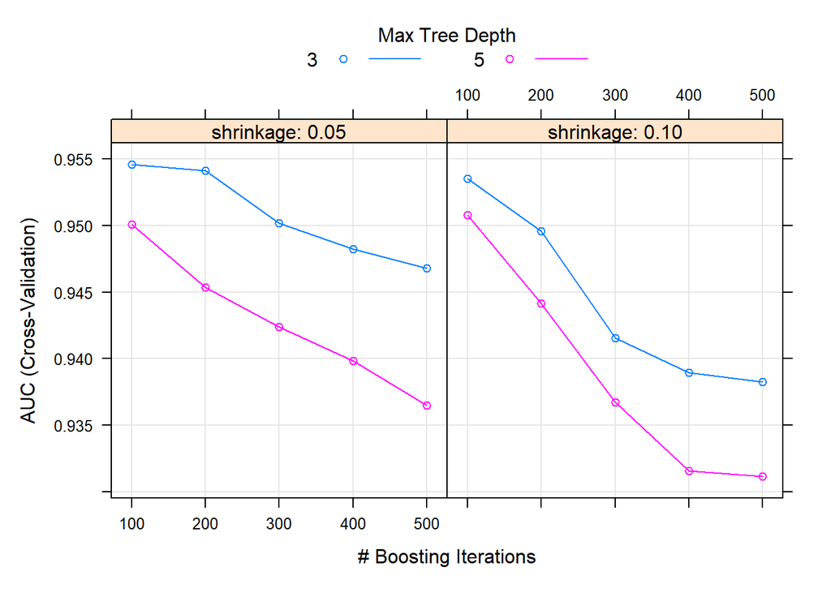

```r
plot(gbm_fit)
```

Selecting the best model is below:

Let’s analyze this model with test data finally.

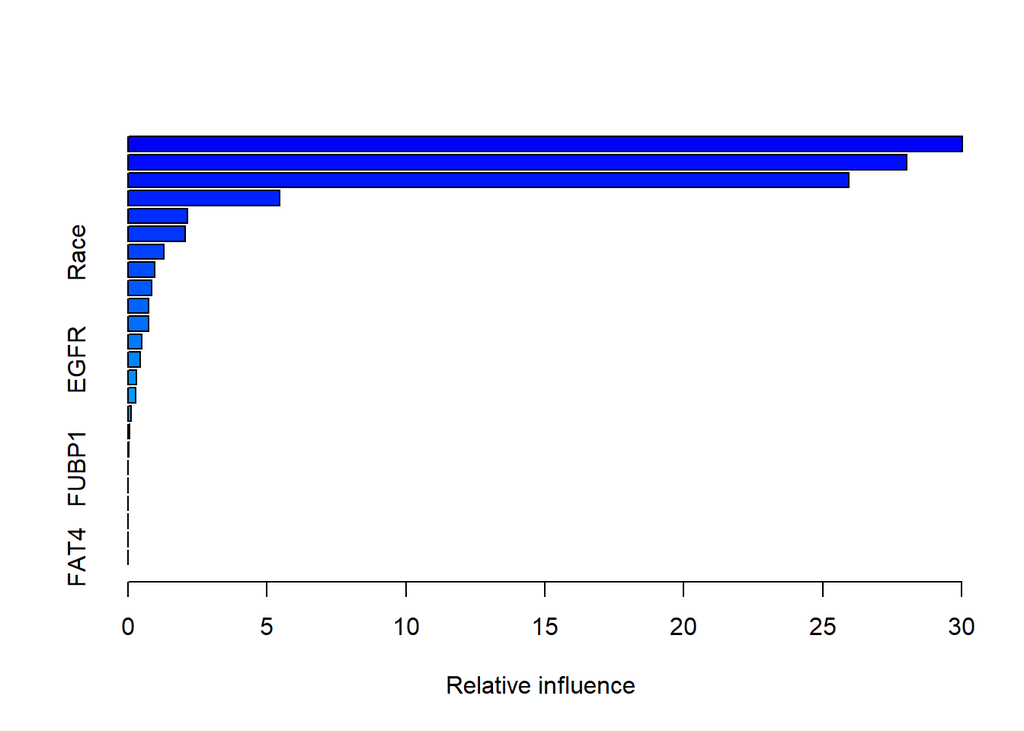

```
##                               var     rel.inf
## Age_at_diagnosis Age_at_diagnosis 30.02510932
## IDH1MUTATED           IDH1MUTATED 28.03828341
## IDH1NOT_MUTATED   IDH1NOT_MUTATED 25.95607057
## PTEN                         PTEN  5.45976493
## ATRX                         ATRX  2.14229913
## CIC                           CIC  2.06119358
## Race                         Race  1.29995976
## NOTCH1                     NOTCH1  0.95667644
## Gender                     Gender  0.85967408
## MUC16                       MUC16  0.74329209
## RB1                           RB1  0.73711108
## NF1                           NF1  0.50996934
## EGFR                         EGFR  0.43931323
## PIK3R1                     PIK3R1  0.30079780
## TP53                         TP53  0.26800609
## PDGFRA                     PDGFRA  0.12103706
## PIK3CA                     PIK3CA  0.05235090
## IDH2                         IDH2  0.02909121
## FUBP1                       FUBP1  0.00000000
## BCOR                         BCOR  0.00000000
## CSMD3                       CSMD3  0.00000000
## SMARCA4                   SMARCA4  0.00000000
## GRIN2A                     GRIN2A  0.00000000
## FAT4                         FAT4  0.00000000
```

```r
noftrees=100
depth=3
learning_rate=0.1

boosting_model=gbm(Grade~., data=gbm_train,distribution = 'multinomial', n.trees = noftrees,
                   interaction.depth = depth, n.minobsinnode = 10, shrinkage =learning_rate, cv.folds = 10)

summary(boosting_model)
```

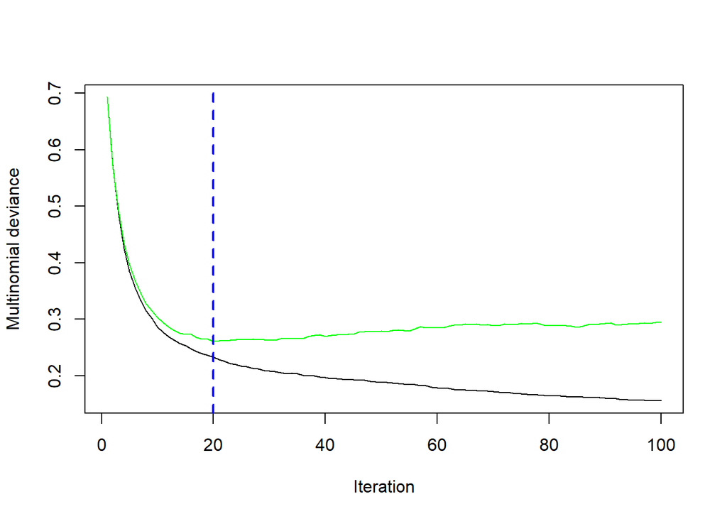

```
## [1] 20
```

```r
gbm.perf(boosting_model, method = "cv")
```

```r
prediction.train <- predict(boosting_model, newdata = gbm_train, type = "response")


predicted_classes <- apply(prediction.train, 1, which.max)


# Create a confusion matrix
conf_matrix <- table(gbm_train$Grade, predicted_classes)

# Print the confusion matrix
print(conf_matrix)
```

```
##      predicted_classes
##         1   2
##   GBM 210  28
##   LGG  20 330
```

Also analyzing with the test data:

```r
prediction.test <- predict(boosting_model, newdata = gbm_test, type = "response")


predicted_classes <- apply(prediction.test, 1, which.max)


# Create a confusion matrix
conf_matrix <- table(gbm_test$Grade, predicted_classes)

# Print the confusion matrix
print(conf_matrix)
```

```
##      predicted_classes
##         1   2
##   GBM  81  21
##   LGG  15 134
```

```r
# Calculate accuracy
accuracy <- sum(diag(conf_matrix)) / sum(conf_matrix)

# Print the accuracy
print(accuracy)
```

```
## [1] 0.8565737
```

Let’s move on with the fifth dataset which is about the predicting Total Power of Large scale wave energy.

## Large-scale Wave Energy Case

### Part 5.0 : Explaining the Large-scale Wave Energy Case and loading the data.

Wave energy is a rapidly advancing and promising renewable energy source that holds great potential for addressing the challenges of global warming and climate change. However, optimizing energy output in large wave farms presents a complex problem due to the expensive calculations required to account for hydrodynamic interactions between wave energy converters (WECs). Developing a fast and accurate surrogate model is crucial to overcome these challenges. In light of this, we have compiled an extensive WEC dataset that includes 54,000 and 9,600 configurations involving 49 and 100 WECs, coordination, power, q-factor, and total farm power output.

This dataset was created to develop a fast and effective surrogate model for estimating the total power out of the large wave farm accurately.

Also, this dataset has >100 features, and since the target class is continuous variable, we need to implement regression model on this problem.

```r
energy_data_path <- paste0(data_path,"WaveEnergy/energy.csv")

energy_data <- read.csv(energy_data_path)

head(energy_data)
```

```
##    X1 Y1     X2    Y2     X3    Y3     X4     Y4  X5  Y5     X6     Y6     X7
## 1 600  0 546.16 37.50 489.79 74.88 432.47 112.05 650   0 700.00   0.00 750.00
## 2 593 12 546.16 37.50 489.79 74.88 432.47 112.05 644   8 700.00   0.00 750.00
## 3 593 12 546.16 37.50 489.79 74.88 432.47 112.05 644   8 697.00   3.00 750.00
## 4 593 12 546.16 37.50 489.79 74.88 432.47 112.05 644   8 697.00   3.00 750.00
## 5 200  0 146.17 37.53  89.76 74.93  32.40 112.18 400   0 346.17  37.53 289.76
## 6 600  0 546.17 37.53 489.76 74.93 432.40 112.18 200 200 146.17 237.53  89.76
##       Y7    X8     Y8  X9  Y9    X10    Y10    X11    Y11    X12    Y12  X13
## 1   0.00 800.0   0.00 850   0 900.00   0.00 950.00   0.00 1000.0   0.00 1000
## 2   0.00 800.0   0.00 850   0 900.00   0.00 950.00   0.00 1000.0   0.00 1000
## 3   0.00 800.0   0.00 850   0 900.00   0.00 950.00   0.00 1000.0   0.00 1000
## 4   0.00 800.0   0.00 850   0 900.00   0.00 950.00   0.00 1000.0   0.00 1000
## 5  74.93 232.4 112.18 800   0 746.17  37.53 689.76  74.93  632.4 112.18 1000
## 6 274.93  32.4 312.18 600 200 546.17 237.53 489.76 274.93  432.4 312.18  400
##   Y13    X14    Y14    X15    Y15    X16    Y16 X17 Y17    X18    Y18    X19
```

[output cut: 90 more lines]

### Part 5.1 : Data Analysis & Exploring Data & Preprocessing

```r
dim(energy_data)
```

```
## [1] 36043   149
```

```r
str(energy_data)
```

```
## 'data.frame':    36043 obs. of  149 variables:
##  $ X1         : num  600 593 593 593 200 600 600 400 800 800 ...
##  $ Y1         : num  0 12 12 12 0 0 0 0 0 0 ...
##  $ X2         : num  546 546 546 546 146 ...
##  $ Y2         : num  37.5 37.5 37.5 37.5 37.5 ...
##  $ X3         : num  489.8 489.8 489.8 489.8 89.8 ...
##  $ Y3         : num  74.9 74.9 74.9 74.9 74.9 ...
##  $ X4         : num  432.5 432.5 432.5 432.5 32.4 ...
##  $ Y4         : num  112 112 112 112 112 ...
##  $ X5         : num  650 644 644 644 400 200 800 600 1000 1000 ...
##  $ Y5         : num  0 8 8 8 0 200 0 0 0 0 ...
##  $ X6         : num  700 700 697 697 346 ...
##  $ Y6         : num  0 0 3 3 37.5 ...
##  $ X7         : num  750 750 750 750 290 ...
##  $ Y7         : num  0 0 0 0 74.9 ...
```

[output cut: 86 more lines]

```r
summary(energy_data)
```

```
##        X1                Y1               X2               Y2
##  Min.   :   0.00   Min.   :  0.00   Min.   :   0.0   Min.   :  0.00
##  1st Qu.:  65.77   1st Qu.:  0.00   1st Qu.: 200.0   1st Qu.:  0.00
##  Median : 250.00   Median :  0.00   Median : 346.1   Median : 37.52
##  Mean   : 366.60   Mean   : 18.71   Mean   : 426.3   Mean   : 51.09
##  3rd Qu.: 600.00   3rd Qu.:  0.00   3rd Qu.: 746.0   3rd Qu.: 37.90
##  Max.   :1000.00   Max.   :885.59   Max.   :1000.0   Max.   :939.26
##        X3               Y3               X4               Y4
##  Min.   :   0.0   Min.   :  0.00   Min.   :   0.0   Min.   :  0.00
##  1st Qu.: 289.9   1st Qu.: 50.00   1st Qu.: 300.0   1st Qu.: 50.00
##  Median : 400.0   Median : 74.82   Median : 500.0   Median :100.00
##  Mean   : 477.3   Mean   : 57.85   Mean   : 497.2   Mean   : 73.32
##  3rd Qu.: 689.8   3rd Qu.: 74.96   3rd Qu.: 632.8   3rd Qu.:112.15
##  Max.   :1000.0   Max.   :990.00   Max.   :1000.0   Max.   :990.00
##        X5               Y5               X6               Y6
##  Min.   :   0.0   Min.   :  0.00   Min.   :   0.0   Min.   :  0.000
##  1st Qu.: 600.0   1st Qu.:  0.00   1st Qu.: 546.1   1st Qu.:  1.935
##  Median : 700.0   Median :  0.08   Median : 750.0   Median : 37.570
##  Mean   : 684.3   Mean   : 44.01   Mean   : 707.5   Mean   : 55.942
##  3rd Qu.: 850.0   3rd Qu.: 50.00   3rd Qu.: 900.0   3rd Qu.: 50.000
##  Max.   :1000.0   Max.   :919.59   Max.   :1000.0   Max.   :990.000
##        X7               Y7               X8                Y8
##  Min.   :   0.0   Min.   :  0.00   Min.   :   0.00   Min.   :   0.0
##  1st Qu.: 689.6   1st Qu.:  0.00   1st Qu.:  85.48   1st Qu.: 100.0
##  Median : 850.0   Median : 74.82   Median : 432.66   Median : 112.2
##  Mean   : 755.3   Mean   : 68.10   Mean   : 464.78   Mean   : 145.9
##  3rd Qu.: 960.8   3rd Qu.:100.00   3rd Qu.: 800.00   3rd Qu.: 200.0
##  Max.   :1000.0   Max.   :578.22   Max.   :1000.00   Max.   :1000.0
##        X9               Y9             X10              Y10
##  Min.   :   0.0   Min.   :  0.0   Min.   :   0.0   Min.   :  0.0
##  1st Qu.: 200.0   1st Qu.: 50.0   1st Qu.: 346.0   1st Qu.: 50.0
##  Median : 400.0   Median :184.9   Median : 450.0   Median :150.0
##  Mean   : 513.4   Mean   :151.9   Mean   : 527.3   Mean   :157.5
##  3rd Qu.: 800.0   3rd Qu.:200.0   3rd Qu.: 750.0   3rd Qu.:237.5
##  Max.   :1000.0   Max.   :931.8   Max.   :1000.0   Max.   :990.0
##       X11              Y11             X12              Y12
##  Min.   :   0.0   Min.   :  0.0   Min.   :   0.0   Min.   :  0.0
##  1st Qu.: 434.6   1st Qu.:100.0   1st Qu.: 432.2   1st Qu.:112.2
##  Median : 550.0   Median :200.0   Median : 650.0   Median :200.0
##  Mean   : 571.5   Mean   :179.0   Mean   : 590.7   Mean   :188.1
```

[output cut: 211 more lines]

```
##  Max.   :109400   Max.   :114195   Max.   :106702   Max.   :104751
##     Power47          Power48          Power49             qW
##  Min.   : 63028   Min.   : 61717   Min.   : 47257   Min.   :0.7200
##  1st Qu.: 97155   1st Qu.: 96870   1st Qu.: 96320   1st Qu.:0.8100
##  Median : 99806   Median : 98711   Median : 96543   Median :0.8300
##  Mean   : 98106   Mean   : 97463   Mean   : 96135   Mean   :0.8338
##  3rd Qu.:100955   3rd Qu.: 99064   3rd Qu.: 97036   3rd Qu.:0.8600
##  Max.   :102892   Max.   :102275   Max.   :101876   Max.   :0.8800
##   Total_Power
##  Min.   :3388944
##  1st Qu.:3847335
##  Median :3931541
##  Mean   :3938246
##  3rd Qu.:4063623
##  Max.   :4177659
```

Analyzing the data whether it has null values. If it has, then we need to handle the missing values.

```r
colSums(sapply(energy_data, is.na))
```

```
##          X1          Y1          X2          Y2          X3          Y3
##           0           0           0           0           0           0
##          X4          Y4          X5          Y5          X6          Y6
##           0           0           0           0           0           0
##          X7          Y7          X8          Y8          X9          Y9
##           0           0           0           0           0           0
##         X10         Y10         X11         Y11         X12         Y12
##           0           0           0           0           0           0
##         X13         Y13         X14         Y14         X15         Y15
##           0           0           0           0           0           0
##         X16         Y16         X17         Y17         X18         Y18
##           0           0           0           0           0           0
##         X19         Y19         X20         Y20         X21         Y21
##           0           0           0           0           0           0
##         X22         Y22         X23         Y23         X24         Y24
##           0           0           0           0           0           0
##         X25         Y25         X26         Y26         X27         Y27
##           0           0           0           0           0           0
##         X28         Y28         X29         Y29         X30         Y30
##           0           0           0           0           0           0
##         X31         Y31         X32         Y32         X33         Y33
##           0           0           0           0           0           0
##         X34         Y34         X35         Y35         X36         Y36
##           0           0           0           0           0           0
##         X37         Y37         X38         Y38         X39         Y39
##           0           0           0           0           0           0
##         X40         Y40         X41         Y41         X42         Y42
##           0           0           0           0           0           0
##         X43         Y43         X44         Y44         X45         Y45
##           0           0           0           0           0           0
##         X46         Y46         X47         Y47         X48         Y48
##           0           0           0           0           0           0
##         X49         Y49      Power1      Power2      Power3      Power4
##           0           0           0           0           0           0
##      Power5      Power6      Power7      Power8      Power9     Power10
##           0           0           0           0           0           0
##     Power11     Power12     Power13     Power14     Power15     Power16
##           0           0           0           0           0           0
##     Power17     Power18     Power19     Power20     Power21     Power22
##           0           0           0           0           0           0
##     Power23     Power24     Power25     Power26     Power27     Power28
##           0           0           0           0           0           0
##     Power29     Power30     Power31     Power32     Power33     Power34
##           0           0           0           0           0           0
##     Power35     Power36     Power37     Power38     Power39     Power40
##           0           0           0           0           0           0
##     Power41     Power42     Power43     Power44     Power45     Power46
##           0           0           0           0           0           0
##     Power47     Power48     Power49          qW Total_Power
##           0           0           0           0           0
```

Can be seen in the data, there is no missing values, which is a good sign for us. We need to get rid of the duplicated values.

```r
energy_data <- energy_data[!duplicated(energy_data), ]
```

We are ready to move on. Let’s make some visualizations to understand data more.

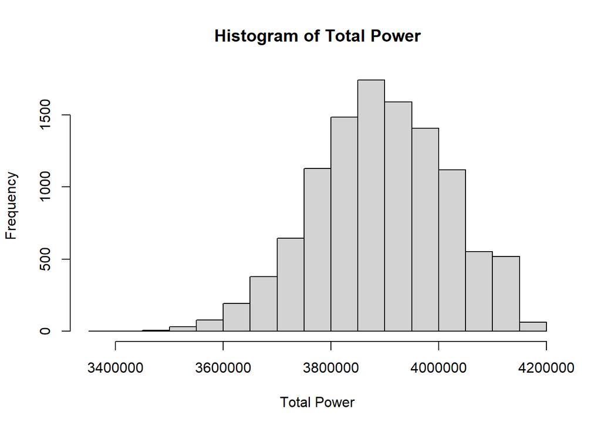

```r
hist(energy_data$Total_Power, main = "Histogram of Total Power", xlab = "Total Power")
```

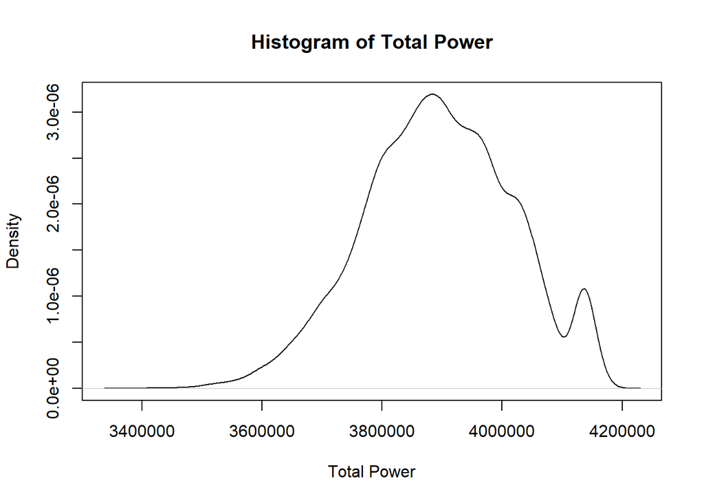

```r
plot(density(energy_data$Total_Power), main = "Histogram of Total Power", xlab = "Total Power")
```

### Part 5.2 : Train & Test Split for Modeling (Scaled Split)

In order to train the model and then the test its performance, we need to split the data as training and test datasets. Before hand, we also need to scale the features (except the target feature) while using the K-Nearest-Neighbor algorithm since it is highly affected from feature’s scale.

In order not to mutate the main dataset, we’ll copy it and then make the scale and split operation.

```r
scaled_energy_data <- energy_data
scaled_energy_data[,-149] <- scale(scaled_energy_data[,-149])

validationIndex <- createDataPartition(scaled_energy_data$Total_Power, p=0.70, list=FALSE)

knn_train <- scaled_energy_data[validationIndex,] # 70% of data to training
knn_test <- scaled_energy_data[-validationIndex,]


cat("Dimension of the main dataset:",dim(scaled_energy_data))
```

```
## Dimension of the main dataset: 10936 149
```

```r
cat("Dimension of the train dataset:",dim(knn_train))
```

```
## Dimension of the train dataset: 7656 149
```

```r
cat("Dimension of the test dataset:",dim(knn_test))
```

```
## Dimension of the test dataset: 3280 149
```

Dataset is scaled, has no missing and duplicated values. It is ready to be used in algorithms.

### Part 5.3 : kNN Algorithm (k-Nearest Neighbor Regressor)

Let’s start with the kNN algorithm. The algorithm is based on the idea that similar data points tend to be close to each other in the feature space. In other words, the class or value of an unknown data point can be predicted by examining its k-nearest neighbors.

There is a parameters to consider: the distance measure and the number of neighbors.

Differen than classification cross-validation, we we are going to use the knn.reg function of R and the comparing metric will be Mean Squared Error of models.

```r
set.seed(25)

# knn CV
k_values <- c(1, 2, 3, 5, 7, 10, 15, 20)

# Create an empty data frame to store results
knn_results <- data.frame(k = numeric(0), MSE = numeric(0))

# Perform grid search
for (k in k_values) {
  knn_model <- knn.reg(knn_train[,-149],y = knn_train$Total_Power,k=k)

  mse <- round(mean(sqrt((knn_model$pred - knn_train$Total_Power)^2)),3)

  # Store the results
  knn_results <- rbind(knn_results, data.frame(k = k, MSE = mse))
}

# Print the results
print(knn_results)
```

```
##    k      MSE
## 1  1 42646.04
## 2  2 37658.92
## 3  3 36134.64
## 4  5 35385.10
## 5  7 35980.43
## 6 10 36772.26
## 7 15 38231.38
## 8 20 39529.80
```

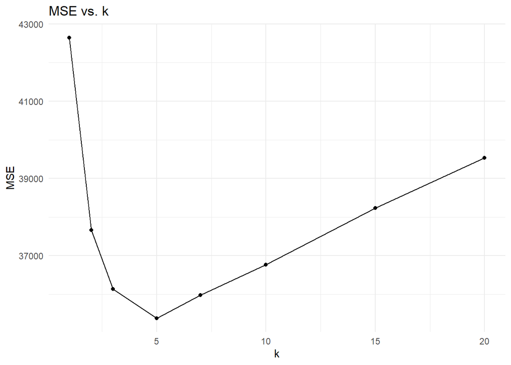

```r
ggplot(knn_results, aes(x = k, y = MSE)) +
  geom_line() +
  geom_point() +
  labs(title = "MSE vs. k",
       x = "k",
       y = "MSE") +
  theme_minimal()
```

After the report of the CV and the plot shows that the final value used for the model was k = 5 and it is the optimum k value for the model with respect to MSE.

Regression metrics for k = 5 is as follows:

```r
# Test using test data
knn_best <- knn.reg(knn_test[,-149],y = knn_test$Total_Power,k= 5)

predictions <- knn_best$pred
true_values <- knn_test$Total_Power

# Calculate Mean Absolute Error (MAE)
mae <- mean(abs(predictions - true_values))
print(paste("Mean Absolute Error (MAE):", mae))
```

```
## [1] "Mean Absolute Error (MAE): 41362.2795743902"
```

```r
# Calculate Root Mean Squared Error (RMSE)
rmse <- sqrt(mean((predictions - true_values)^2))
print(paste("Root Mean Squared Error (RMSE):", rmse))
```

```
## [1] "Root Mean Squared Error (RMSE): 59158.6985866678"
```

```r
# Calculate R-squared (R²)
sse <- sum((predictions - true_values)^2)
sst <- sum((true_values - mean(true_values))^2)
rsquared <- 1 - (sse / sst)
print(paste("R-squared (R²):", rsquared))
```

```
## [1] "R-squared (R²): 0.771441311653121"
```

### Part 5.4 : Decision Tree Algorithm (Regression)

Let’s move with the second one which is the Decision Tree (DT) algorithm.

First, arranging the dataset in order not to mutate original one, we copy from it.

```r
# Copying the main dataset
energy_data_dt <- data.table(energy_data)

dim(energy_data_dt)
```

```
## [1] 10936   149
```

```r
# Remove rows with any NA values
energy_data_dt <- na.omit(energy_data_dt)
validationIndex <- createDataPartition(energy_data_dt$Total_Power, p=0.70, list=FALSE)

dt_train <- energy_data_dt[validationIndex,] # 70% of data to training
dt_test <- energy_data_dt[-validationIndex,]

cat("Dimension of the main dataset:",dim(energy_data_dt))
```

```
## Dimension of the main dataset: 10936 149
```

```r
cat("Dimension of the train dataset:",dim(dt_train))
```

```
## Dimension of the train dataset: 7656 149
```

```r
cat("Dimension of the test dataset:",dim(dt_test))
```

```
## Dimension of the test dataset: 3280 149
```

Dataset is ready to be learned and now we are going to implement a manual cross validation to tune the hyperparameters for the decision tree and we are going to look at its MSE value in each iteration.

Assuming the tuning hyperparameter will be only the minimal number of observations per tree leaf. Setting complexity parameter to zero and minimum number of observations to split as the twice as the minimal number of observations per tree leaf.

In the end, we are going to store them in df to find the best model.

```r
cv_results <- data.frame(minbucket = numeric(), RMSE = numeric())

set.seed(10)

# Define a range of minsplit values to try
minbucket_values <- c(1, 5, 10, 15, 20)

# Perform cross-validation for each minbucket value
for (minbucket_val in minbucket_values) {
  # Create a decision tree regression model with the current minbucket value
  tree_model <- rpart(Total_Power~.,dt_train,method='anova',
                      control=rpart.control(cp=0, minbucket = minbucket_val, minsplit = 2*minbucket_val))

  predictions <- predict(tree_model, newdata = dt_train)

  true_values <- dt_train$Total_Power

  rmse <- round(sqrt(mean((predictions - true_values)^2)),3)

  # Store the results in the data frame
  cv_results <- rbind(cv_results, data.frame(minbucket = minbucket_val, RMSE = rmse))
}

# Print the cross-validation results
print(cv_results)
```

```
##   minbucket      RMSE
## 1         1   295.760
## 2         5  5468.571
## 3        10  8258.759
## 4        15  9472.276
## 5        20 10323.856
```

```r
minbucket_val <- 5
best_tree_model <- rpart(Total_Power~.,dt_train,method='anova',
                         control=rpart.control(cp=0, minbucket = minbucket_val, minsplit = 2*minbucket_val))

# Make predictions on the test set
predictions <- predict(best_tree_model, newdata = dt_test)

# True values from the test set
true_values <- dt_test$Total_Power

# Calculate Mean Absolute Error (MAE)
mae <- mean(abs(predictions - true_values))
print(paste("Mean Absolute Error (MAE):", mae))
```

```
## [1] "Mean Absolute Error (MAE): 11533.9168665421"
```

```r
# Calculate Root Mean Squared Error (RMSE)
rmse <- round(sqrt(mean((predictions - true_values)^2)),3)
print(paste("Root Mean Squared Error (RMSE):", rmse))
```

```
## [1] "Root Mean Squared Error (RMSE): 15369.853"
```

```r
# Calculate R-squared (R²)
sse <- sum((predictions - true_values)^2)
sst <- sum((true_values - mean(true_values))^2)
rsquared <- 1 - (sse / sst)
print(paste("R-squared (R²):", rsquared))
```

```
## [1] "R-squared (R²): 0.984671755004113"
```

Its Error metrics is quite low with respect to problem size and R^2 is near 99%

Finally, we can look its predictions vs. actuals as a scatter plot.

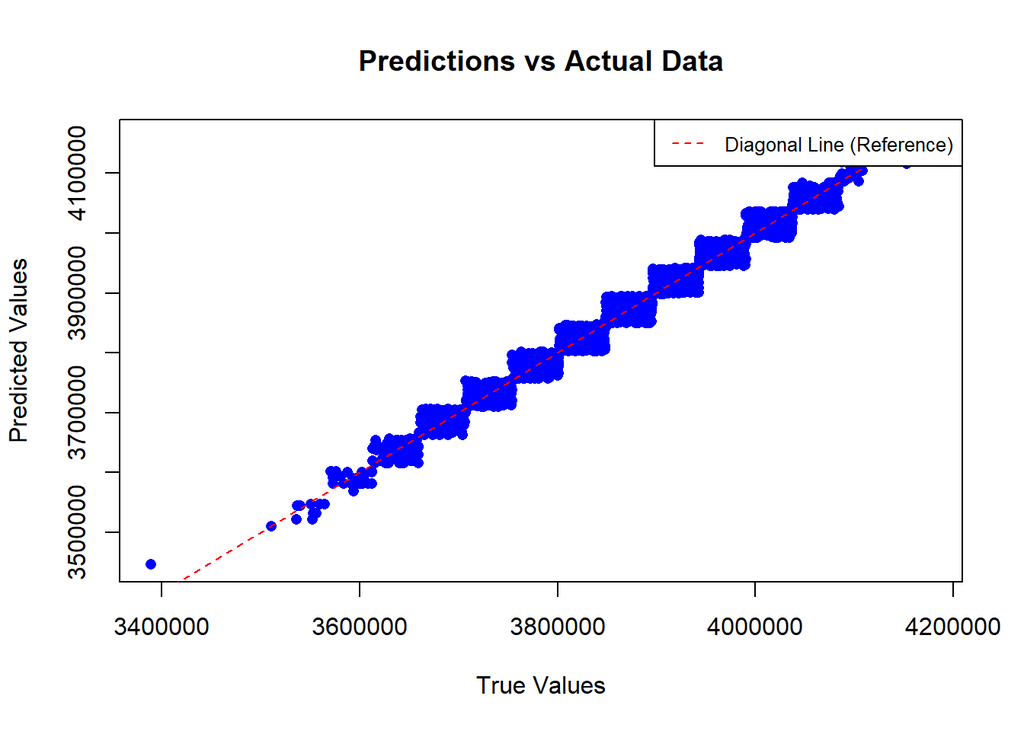

```r
# Create a scatterplot
plot(true_values, predictions,
     main = "Predictions vs Actual Data",
     xlab = "True Values",
     ylab = "Predicted Values",
     pch = 16,  # Set the point character
     col = "blue"  # Set the point color
)

# Add a diagonal line for reference
abline(0, 1, col = "red", lty = 2)

# Add a legend
legend("topright", legend = "Diagonal Line (Reference)", col = "red", lty = 2, cex = 0.8)
```

### Part 5.5 : Random Forest Algorithm (Regression)

Let’s move with the third one which is the Random Forest (RF) algorithm.

First, arranging the dataset in order not to mutate original one, we copy from it.

```r
# Copying the main dataset
energy_data_rf <- data.table(energy_data)

dim(energy_data_rf)
```

```
## [1] 10936   149
```

```r
validationIndex <- createDataPartition(energy_data_rf$Total_Power, p=0.70, list=FALSE)

rf_train <- energy_data_rf[validationIndex,] # 70% of data to training
rf_test <- energy_data_rf[-validationIndex,]

cat("Dimension of the main dataset:",dim(energy_data_rf))
```

```
## Dimension of the main dataset: 10936 149
```

```r
cat("Dimension of the train dataset:",dim(rf_train))
```

```
## Dimension of the train dataset: 7656 149
```

```r
cat("Dimension of the test dataset:",dim(rf_test))
```

```
## Dimension of the test dataset: 3280 149
```

Dataset is ready to be learned and now we are going to implement a manual cross validation to tune the hyperparameters for the random forest and we are going to look at its error value in each iteration.

Assuming the tuning hyperparameter will be only the effect of the ratio of the number of features evaluated at each split (mtry) and setting other parameters as J=500 and the minimal number of observations per tree leaf=5.

In the end, we are going to store them in table to find the best model.

```r
set.seed(12)
# Set the number of trees and nodesize
num_trees <- 500
min_obs_per_leaf <- 5

# Create a grid of mtry values to explore
mtry_values <- c(2, 4, 6, 8, 10)  # Add more values as needed

# Create an empty data frame to store results
rf_results <- data.frame(mtry = numeric(), RMSE = numeric())

# Perform grid search
for (m in mtry_values) {
  # Train the Random Forest model
  rf_model <- randomForest(Total_Power ~ ., data = rf_train,
                           ntree = num_trees, nodesize = min_obs_per_leaf, mtry = m)

  # Make predictions on the training set
  predictions <- predict(rf_model, newdata = rf_train)

  true_values <- rf_train$Total_Power

  rmse <- round(sqrt(mean((predictions - true_values)^2)),3)

  # Store the results in the data frame
  rf_results <- rbind(rf_results, data.frame(mtry = m, RMSE = rmse))
}

# Print the results
print(rf_results)
```

```
##   mtry     RMSE
## 1    2 20410.12
## 2    4 15653.52
## 3    6 13656.11
## 4    8 12184.03
## 5   10 11246.06
```

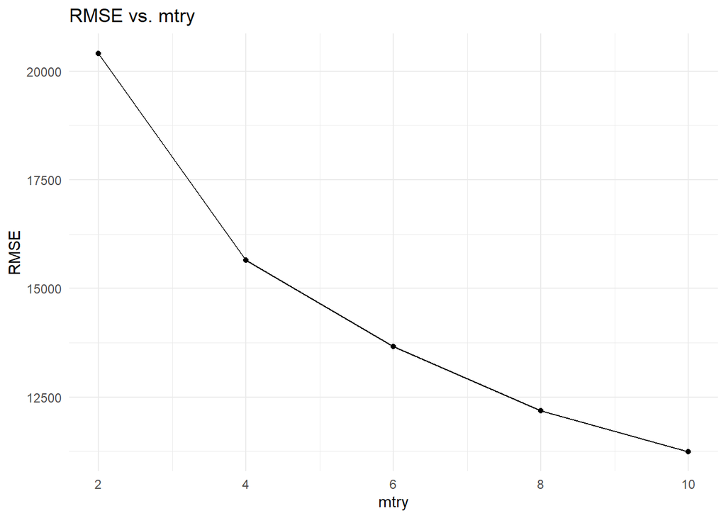

```r
ggplot(rf_results, aes(x = mtry, y = RMSE)) +
  geom_line() +
  geom_point() +
  labs(title = "RMSE vs. mtry",
       x = "mtry",
       y = "RMSE") +
  theme_minimal()
```

Looks like the model with `mtry` = 10 (given `ntree` = 500 & `nodesize` = 5) is the best model in terms of RMSE, lets also analyze the other metrics using test dataset.

```r
best_rf_model <- randomForest(Total_Power ~ ., data = rf_train,
                              ntree = num_trees, nodesize = min_obs_per_leaf, mtry = 10)

# Make predictions on the test set
predictions <- predict(best_rf_model, newdata = rf_test)

# True values from the test set
true_values <- rf_test$Total_Power

# Calculate Mean Absolute Error (MAE)
mae <- mean(abs(predictions - true_values))
print(paste("Mean Absolute Error (MAE):", mae))
```

```
## [1] "Mean Absolute Error (MAE): 17592.3394944111"
```

```r
# Calculate Root Mean Squared Error (RMSE)
rmse <- round(sqrt(mean((predictions - true_values)^2)),3)
print(paste("Root Mean Squared Error (RMSE):", rmse))
```

```
## [1] "Root Mean Squared Error (RMSE): 27351.567"
```

```r
# Calculate R-squared (R²)
sse <- sum((predictions - true_values)^2)
sst <- sum((true_values - mean(true_values))^2)
rsquared <- 1 - (sse / sst)
print(paste("R-squared (R²):", rsquared))
```

```
## [1] "R-squared (R²): 0.952074822512461"
```

Finally, let’s look at the variable importance and the partial dependence plots. VarImp plot basically shows which feature has the most contribution to the model while it is improving (making purer). Partial Dependence plot is the plot showing the effect of selected feature to the predictions.

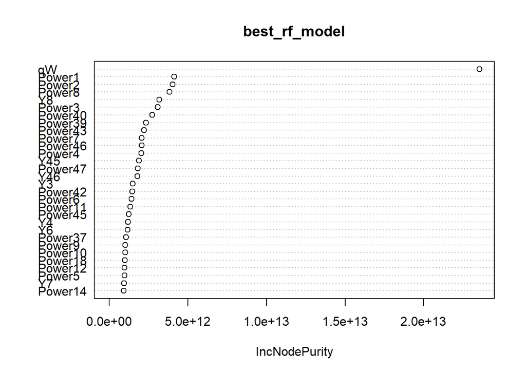

```r
# Plot variable importance
varImpPlot(best_rf_model)
```

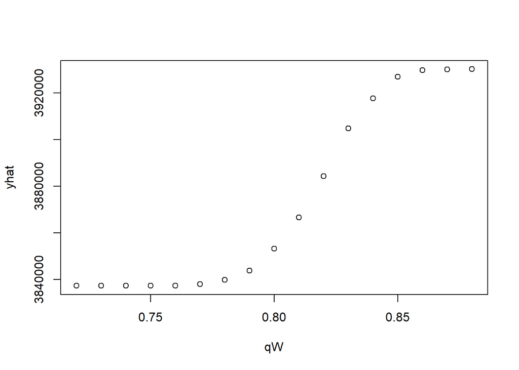

```r
# Create partial dependence plot
partial_plot <- partial(best_rf_model, pred.var = 'qW', data = dt_test)

# Plot the partial dependence plot
plot(partial_plot)
```

### Part 5.6 : GBM Algorithm

First, arranging the dataset in order not to mutate original one, we copy from it.

```r
energy_data_gbm <- data.table(energy_data)

dim(energy_data_gbm)
```

```
## [1] 10936   149
```

```r
validationIndex <- createDataPartition(energy_data_gbm$Total_Power, p=0.70, list=FALSE)

gbm_train <- energy_data_gbm[validationIndex,] # 70% of data to training
gbm_test <- energy_data_gbm[-validationIndex,]

cat("Dimension of the main dataset:",dim(energy_data_gbm))
```

```
## Dimension of the main dataset: 10936 149
```

```r
cat("Dimension of the train dataset:",dim(gbm_train))
```

```
## Dimension of the train dataset: 7656 149
```

```r
cat("Dimension of the test dataset:",dim(gbm_test))
```

```
## Dimension of the test dataset: 3280 149
```

Let’s tune the hyperparameters of the GBM with respect to the “RMSE” value.

We are mainly interested in tuning the depth (interaction.depth), the number of trees (n.trees) and the learning rate (shrinkage). Also, I have took a help from the lecture notes in this part.

```r
set.seed(10)

n_folds=10

fitControl=trainControl(method = "cv",
                        number = n_folds)
## gradient boosting
gbmGrid=expand.grid(interaction.depth = c(3, 5),
                    n.trees = c(1:5)*100,
                    shrinkage = c(0.05,0.1),
                    n.minobsinnode = 10)
set.seed(1)
gbm_fit=train(Total_Power ~ ., data = gbm_train,
              method = "gbm",
              trControl = fitControl, metric='RMSE',
              tuneGrid = gbmGrid,
              verbose=F) #verbose is an argument from gbm, prints to screen
gbm_fit
```

```
## Stochastic Gradient Boosting
##
## 7656 samples
##  148 predictor
##
## No pre-processing
## Resampling: Cross-Validated (10 fold)
## Summary of sample sizes: 6891, 6891, 6889, 6890, 6891, 6891, ...
## Resampling results across tuning parameters:
##
##   shrinkage  interaction.depth  n.trees  RMSE      Rsquared   MAE
##   0.05       3                  100      13646.22  0.9883086  11453.758
##   0.05       3                  200      13081.17  0.9890053  11090.767
##   0.05       3                  300      12885.34  0.9893420  10922.779
##   0.05       3                  400      12736.10  0.9895883  10780.404
##   0.05       3                  500      12613.17  0.9897888  10647.811
##   0.05       5                  100      13397.03  0.9885853  11242.462
##   0.05       5                  200      12901.40  0.9893127  10904.702
##   0.05       5                  300      12688.29  0.9896678  10693.111
##   0.05       5                  400      12529.44  0.9899257  10524.482
##   0.05       5                  500      12404.39  0.9901242  10378.553
##   0.10       3                  100      13080.63  0.9890153  11100.907
##   0.10       3                  200      12753.64  0.9895608  10788.065
##   0.10       3                  300      12551.77  0.9898880  10558.751
##   0.10       3                  400      12348.87  0.9902108  10340.940
##   0.10       3                  500      12207.25  0.9904350  10179.063
##   0.10       5                  100      12903.29  0.9893130  10910.337
##   0.10       5                  200      12537.94  0.9899099  10512.707
##   0.10       5                  300      12312.93  0.9902707  10244.962
##   0.10       5                  400      12130.13  0.9905562  10024.060
##   0.10       5                  500      11934.20  0.9908599   9810.783
##
## Tuning parameter 'n.minobsinnode' was held constant at a value of 10
## RMSE was used to select the optimal model using the smallest value.
## The final values used for the model were n.trees = 500, interaction.depth =
##  5, shrinkage = 0.1 and n.minobsinnode = 10.
```

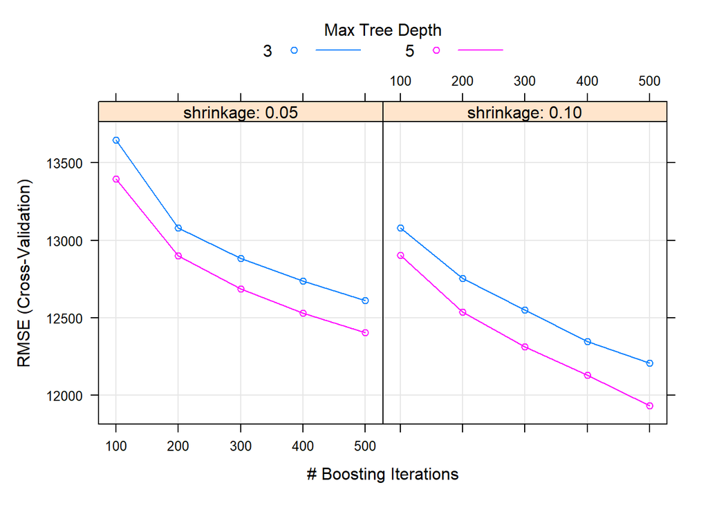

```r
plot(gbm_fit)
```

Selecting the best model is below:

Looks like the best GBM model with the parameters (Shrinkage = 0.1, depth = 5, n.trees = 500).

Let’s analyze this model with test data finally.

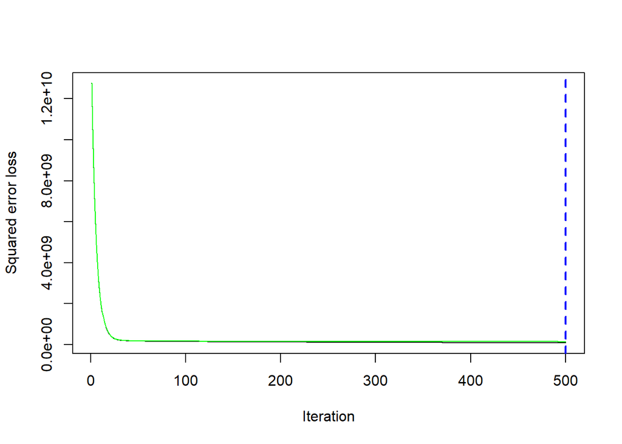

```
## [1] 500
```

```r
noftrees=500
depth=5
learning_rate=0.1

boosting_model=gbm(Total_Power~., data=gbm_train,distribution = 'gaussian', n.trees = noftrees,
                   interaction.depth = depth, n.minobsinnode = 10, shrinkage =learning_rate, cv.folds = 10)

gbm.perf(boosting_model, method = "cv")
```

```r
prediction.test <- predict(boosting_model, newdata = gbm_test, type = "response")

# True values from the test set
true_values <- gbm_test$Total_Power

# Calculate Mean Absolute Error (MAE)
mae <- mean(abs(predictions - true_values))
print(paste("Mean Absolute Error (MAE):", mae))
```

```
## [1] "Mean Absolute Error (MAE): 91959.6903432755"
```

```r
# Calculate Root Mean Squared Error (RMSE)
rmse <- round(sqrt(mean((predictions - true_values)^2)),3)
print(paste("Root Mean Squared Error (RMSE):", rmse))
```

```
## [1] "Root Mean Squared Error (RMSE): 121207.998"
```

### Part 6 : Conclusion & General Comments

All in all, We have worked on 5 different cases, 4 are classification problem and the one is a regression problem. We have implemented 4 main algorithm which are kNN, Decision Tree, Random Forest and GBM. We have analyzed their performances in terms of classification and regression metrics, prediction quality, time complexity. On each dataset, we have developed a best algorithm to explain the dataset well and can predict the future not known labels.

To summary, any problem is unique and depending on the aim metric (accuracy, precision, error rate etc.) and cost (time, money etc.), any algorithm can be used to predict or classify.

```
                                                                                            `Anıl Turgut - 2022702072`
```